# ANÁLISIS DE SINIESTRALIDAD

### CUNEF MUCD (2021/22)

- Aitor Larriona Rementería
- Diego Cendán Bedregal

# Modelos

## LIBRERÍAS

Librerías básicas

```python
import pandas as pd
import matplotlib.pyplot as plt
import numpy as np
import seaborn as sns
import plotly.express as px
from statistics import mode, multimode
import time
import sklearn
import warnings
import scikitplot as skplt
import statsmodels.api as sapi

pd.set_option('display.max_columns', 30)
pd.set_option('display.max_rows', 5000)
```

Funciones para métricas

```python
from sklearn.metrics import roc_auc_score, classification_report, confusion_matrix, roc_curve,precision_score, accuracy_score, f1_score, recall_score
```

Librerías para modelos y para selección de variables

```python
from sklearn.decomposition import PCA
```

```python
from sklearn.feature_selection import SelectFromModel
from sklearn.linear_model import LogisticRegression, LinearRegression
from sklearn.ensemble import RandomForestClassifier
import lightgbm as lgb
import xgboost as xgb
from xgboost import XGBClassifier
```

Importamos el pipeline y pickle (para guardar los modelos)

```python
from sklearn.pipeline import Pipeline
from sklearn.impute import SimpleImputer
from sklearn.compose import ColumnTransformer
import pickle
```

```python
import pyarrow.parquet as pq
import pyarrow as pa
```

Importamos también las funciones necesarias en este notebook del archivo FUNCIONES.py.

```python
import import_ipynb
```

```python
%run FUNCIONES
```

## Lectura de los datos

```python
table_X_train= pq.read_table('/Users/aitor/Desktop/Máster Ciencia de Datos/Aprendizaje automático/Machine-Learning/big practice_data/X_train_oversampled.parquet')
x_train = table_X_train.to_pandas()
```

```python
table_y_train= pq.read_table('/Users/aitor/Desktop/Máster Ciencia de Datos/Aprendizaje automático/Machine-Learning/big practice_data/y_train_oversampled.parquet')
ytrain = table_y_train.to_pandas()
```

```python
table_X_test= pq.read_table('/Users/aitor/Desktop/Máster Ciencia de Datos/Aprendizaje automático/Machine-Learning/big practice_data/x_test.parquet')
x_test = table_X_test.to_pandas()
```

```python
table_y_test= pq.read_table('/Users/aitor/Desktop/Máster Ciencia de Datos/Aprendizaje automático/Machine-Learning/big practice_data/ytest.parquet')
ytest = table_y_test.to_pandas()
```

```python
table = pq.read_table('/Users/aitor/Desktop/Máster Ciencia de Datos/Aprendizaje automático/Machine-Learning/big practice_data/pd_data.parquet')
df_pd_data = table.to_pandas()
```

## MODELO BASE (aleatorio)

En el modelo base trataremos de generar un vector aleatorio de 1s y 2s dando pesos a cada uno de estos dos valores. Los pesos los eligiremos en función de la distribución que tiene nuestra variable target en nuestro dataset. Después de generar este vector aleatorio compararemos el vector real y el predicho para obtener el accuracy del modelo aleatorio principalmente

```python
import random
```

```python
def modelo_base(variable_target):
    predic_modelo_base = list()
    for i in range(len(variable_target)):
        predic_modelo_base.append(random.choices([2,1], [98.315807, 1.684193]))
    #vector_error = variable_target-predic_modelo_base
    return predic_modelo_base#, vector_error
```

```python
predictions_MB = modelo_base(df_pd_data["C_SEV"])
```

```python
print(classification_report(df_pd_data["C_SEV"], predictions_MB))
```

```
              precision    recall  f1-score   support

           1       0.01      0.02      0.02     56857
           2       0.99      0.98      0.98   3845257

    accuracy                           0.97   3902114
   macro avg       0.50      0.50      0.50   3902114
weighted avg       0.97      0.97      0.97   3902114
```

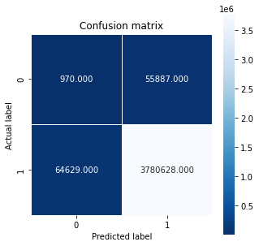

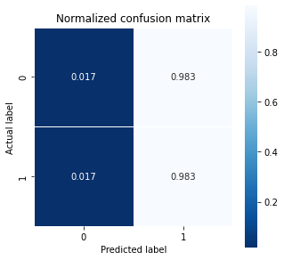

```python
cm_gbt_MB = confusion_matrix(df_pd_data["C_SEV"], predictions_MB)
cm_gbt_norm_MB = confusion_matrix(df_pd_data["C_SEV"], predictions_MB, normalize="true")

plt.figure(figsize=(5,5))
sns.heatmap(cm_gbt_MB, annot=True, fmt=".3f", linewidths=1, square = True, cmap = 'Blues_r');
plt.ylabel('Actual label');
plt.xlabel('Predicted label');
plt.title("Confusion matrix")

plt.figure(figsize=(5,5))
sns.heatmap(cm_gbt_norm_MB, annot=True, fmt=".3f", linewidths=1, square = True, cmap = 'Blues_r');
plt.ylabel('Actual label');
plt.xlabel('Predicted label');
plt.title("Normalized confusion matrix")
```

Podemos observar como el modelo base tiene un accuracy de 0.97 y las matrices de confusión son bastante malas ya que solamente se centran en predecir los no fallecimientos (debido al desbalanceo del dataset). Pero este modelo será nuestro modelo de referencia y, a partir de aquí, los modelos que vayamos obteniendo deberán ir mejorando este.

## LASSO

Lasso es una regularización dentro de las regresiones. Antes de explicar Lasso, debemos explicar qué es una penalización.

**Def.** Una regularización es una penalización. Lo que se busca con la regularización es obligar, de alguna forma, a que el modelo elija las variables más importantes en función de un threshold.

Esto será entendido de manera más clara con el caso particular de regularización *Lasso*

Supongamos que para un modelo dado, calculamos el error cuadrático medio o, también conocido por *MSE*. El error cuadrático medio se define de la siguiente forma:

MSE = $\sum_{i=1}^{M} (y_i - \bar{y}_i)^2$, tal que $\bar{y}_i$ y $y_i$ se refieren al valor predicho y al valor real respectivamente

Donde M es el número de muestras que tenemos. Luego, lo que se pretende hacer con la regularización Lasso es añadir un término de manera que penalice este error cuadrático medio. En otras palabras, el término de Lasso hará mas grande el MSE. Para escribir el desarrollo de manera adecuada, supongamos que tenemos una regresión lineal que se escribe de la siguiente forma:

$\bar{y} = w_{0} + w_{1}*x_{1} + w_{2}*x_{2} + ... + w_{n}*x_{n}$

Luego, nuestra predicción $\bar{y}$ no será mas que $w_{1}*x_{1} + w_{2}*x_{2} + ... + w_{n}*x_{n}$. Entonces, podemos escribir el error cuadrático medio como sigue:

MSE = $\sum_{i=1}^{M} (y_i - w_{0} - \sum_{j=1}^{n}w_{j}*x_{ij})^2$

Ahora, añadimos la penalización Lasso al error cuadrático medio.

MSE = $\sum_{i=1}^{M} (y_i - w_{0} - \sum_{j=1}^{n}w_{j}*x_{ij})^2 + \lambda*\sum_{j=0}^{n}w_{j}^2$ tal que $\lambda \in \mathbb{R}$

Es decir, obligamos a los coeficientes que sean muy bajos para que el error cuadrático medio no aumente exageradamente. El valor $\lambda$ indicará *cuánto quiero que importe esta penalización*. Esto nos dará como resultado que un número de variables serán más importantes que otras.

**Importante.** Para hacer uso de Lasso, es necesario escalar las variables

Una vez vista la teoría, adentrémonos en la práctica.

**Varibales a utilizar**

- *X_train_oversampled*: Dataset de training con la técnica de oversampling sin la variable respuesta
- *y_train_oversampled*: Dataset de training de la variable target con la técnica de oversampling
- *x_test*: Dataset de testing sin la variable target

**Librerias a utilizar**

- SelectFromModel from sklearn.feature_selection
- LogisticRegression, LinearRegression from sklearn.linear_model
- Sklearn.metrics

Primeramente, vamos a comprobar como evoluciona el número de variables y el roc_auc_score en función del threshold para un modelo de regresión logística (nos servirá para más adelante) y así poder elegir el modelo Lasso adeacuado para este modelo

```python
num_var=list()
ROC_score=list()
for i in np.arange(0.05, 0.15, 0.0025):
    sel_lasso = SelectFromModel(LogisticRegression(C=1, penalty='l1', solver='liblinear', max_iter=500), threshold = i)
    sel_lasso.fit(X_train_oversampled, y_train_oversampled)
    selected_feat_lasso = X_train_oversampled.columns[sel_lasso.get_support()]
    model = LogisticRegression(random_state=0)
    model.fit(X_train_oversampled[selected_feat_lasso], y_train_oversampled)
    sel_lasso.get_support()
    predictions_proba=model.predict_proba(x_test[selected_feat_lasso])
    num_var.append(len(selected_feat_lasso))
    ROC_score.append(roc_auc_score(ytest, predictions_proba[:,1]))
    # hacemos print de i para saber en cada momento por qué punto va el bucle
    print(i)
```

```
0.05
0.052500000000000005
0.05500000000000001
```

```
0.05750000000000001
0.06000000000000001
0.06250000000000001
0.06500000000000002
0.06750000000000002
0.07000000000000002
0.07250000000000002
0.07500000000000002
0.07750000000000003
0.08000000000000003
0.08250000000000003
0.08500000000000003
0.08750000000000004
```

```
0.09000000000000004
0.09250000000000004
0.09500000000000004
0.09750000000000004
0.10000000000000005
0.10250000000000005
0.10500000000000005
0.10750000000000005
0.11000000000000006
0.11250000000000006
0.11500000000000006
0.11750000000000006
0.12000000000000006
0.12250000000000007
0.12500000000000006
0.12750000000000006
0.13000000000000006
0.13250000000000006
0.13500000000000006
0.13750000000000007
0.14000000000000007
0.14250000000000007
0.14500000000000007
0.14750000000000008
```

```python
data = {"threshold" :np.arange(0.05, 0.15, 0.0025), 'Num_of_var':num_var, 'roc_score':ROC_score }
threshold_df = pd.DataFrame(data, columns=["threshold", "Num_of_var", "roc_score"])
threshold_df.index=threshold_df["threshold"]
threshold_df.drop("threshold", axis=1)
```

| threshold | Num_of_var | roc_score |
| --- | --- | --- |
| 0.0500 | 27 | 0.750576 |
| 0.0525 | 30 | 0.750521 |
| 0.0550 | 27 | 0.750521 |
| 0.0575 | 29 | 0.750513 |
| 0.0600 | 27 | 0.750580 |
| 0.0625 | 28 | 0.750511 |
| 0.0650 | 25 | 0.750147 |
| 0.0675 | 25 | 0.750151 |
| 0.0700 | 24 | 0.749222 |
| 0.0725 | 27 | 0.749207 |
| 0.0750 | 24 | 0.749196 |
| 0.0775 | 22 | 0.749211 |
| 0.0800 | 22 | 0.749366 |
| 0.0825 | 28 | 0.749208 |
| 0.0850 | 22 | 0.749226 |
| 0.0875 | 24 | 0.749278 |
| 0.0900 | 22 | 0.749277 |
| 0.0925 | 26 | 0.749204 |
| 0.0950 | 18 | 0.749147 |
| 0.0975 | 22 | 0.749278 |
| 0.1000 | 21 | 0.749030 |
| 0.1025 | 21 | 0.749215 |
| 0.1050 | 20 | 0.749354 |
| 0.1075 | 24 | 0.749204 |
| 0.1100 | 21 | 0.747587 |
| 0.1125 | 19 | 0.747490 |
| 0.1150 | 20 | 0.747765 |
| 0.1175 | 26 | 0.747579 |
| 0.1200 | 21 | 0.747617 |
| 0.1225 | 21 | 0.747567 |
| 0.1250 | 24 | 0.747581 |
| 0.1275 | 22 | 0.747404 |
| 0.1300 | 20 | 0.747125 |
| 0.1325 | 18 | 0.747345 |
| 0.1350 | 17 | 0.747377 |
| 0.1375 | 21 | 0.747628 |
| 0.1400 | 15 | 0.747542 |
| 0.1425 | 18 | 0.747402 |
| 0.1450 | 18 | 0.747770 |
| 0.1475 | 22 | 0.747646 |

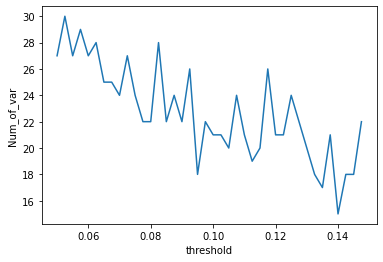

```python
sns.lineplot(data = threshold_df["Num_of_var"])
```

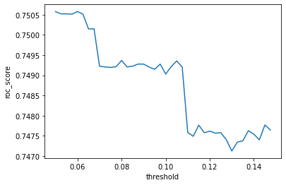

```python
sns.lineplot(data = threshold_df["roc_score"])
```

Viendo las gráficas, vemos que la segunda nos puede aportar quizás más información que la primera. Luego, basándonos en la segunda gráfica, podemos considerar como un buen threshold 0.1 ya que no perdemos mucho roc_auc_score y, nos quedamos con alrededor de 22 variables (gráfica de arriba).

Luego, calculemos Lasso con dicho threshold

**Debido a un problema con este notebook, se ha reiniciado todo y no hemos podido calcular las variables seleccionadas por Lasso.**

```python
start_Lasso = time.time()
```

```python
sel_lasso = SelectFromModel(LogisticRegression(C=1, penalty='l1', solver='liblinear'), threshold = 0.1)
sel_lasso.fit(X_train_oversampled, y_train_oversampled)
```

```python
sel_lasso.get_support()
selected_feat_lasso = X_train_oversampled.columns[sel_lasso.get_support()]
selected_feat_lasso
```

```python
print('total features: {}'.format((X_train_oversampled.shape[1])))
print('selected features: {}'.format(len(selected_feat_lasso)))
```

```python
end_Lasso = time.time()
```

```python
df_coeficientes_lasso = pd.DataFrame(
                        {'predictor': X_train_oversampled.columns,
                         'coef': sel_lasso.estimator_.coef_.flatten()}
                  )

fig, ax = plt.subplots(figsize=(16, 3.84))
ax.stem(df_coeficientes_lasso.predictor, df_coeficientes_lasso.coef, markerfmt=' ')
plt.xticks(rotation=90, ha='right', size=10)
ax.set_xlabel('variable')
ax.set_ylabel('coeficientes')
ax.set_title('Coeficientes del modelo lasso');
```

# SELECCIÓN DE VARIABLES

## PCA

**def**. El PCA o también conocido como análisis de componentes principales, es una técnica de reducción de dimensiones. Esta reducción de dimensiones se intenta que la varianza explicada por ellas sea lo mayor posible.

A continuación mostramos una descripción detallada del algoritmo PCA

El algoritmo tiene distintas fases, que explicamos a continuación:

- *Estandarización de los datos*. Estandarización implica tomar cada valor en una columna y restarle la media de dicha columna y luego dividir por la desviación típica de la columna.
- *Cálculo de la matriz de covarianzas*. La matriz de covarianzas es una matriz simétrica que en la diagonal principal tiene la varianza de las variables y en el resto de elementos (i,j) de la matriz la covarianzas tenemos precisamente la covarianza de los elementos i y j tal que i $\neq$ j.
- *Cálculo de autovalores y autovectores de la matriz de covarianzas*.
- *Ordenación de los autovalores*. La primera de las componentes explica mayor varianza que la segunda (su autovalor es mayor), la segunda explica más que la tercera y así sucesivamente
- *Cálculo de las componentes principales*.

**Vatriables a utilizar**

- *X_train_oversampled*: Dataset de training con la técnica de oversampling sin la variable respuesta
- *x_test*: Dataset de testing sin la variable target

**Librerias a utilizar**

- PCA from sklearn.decomposition

**Importante**: En el algoritmo de PCA necesitamos que las variables estén escaladas.

```python
pca = PCA()

pca.fit(X_train_oversampled)
X_train_pca = pca.transform(X_train_oversampled)
X_test_pca = pca.transform(x_test)
```

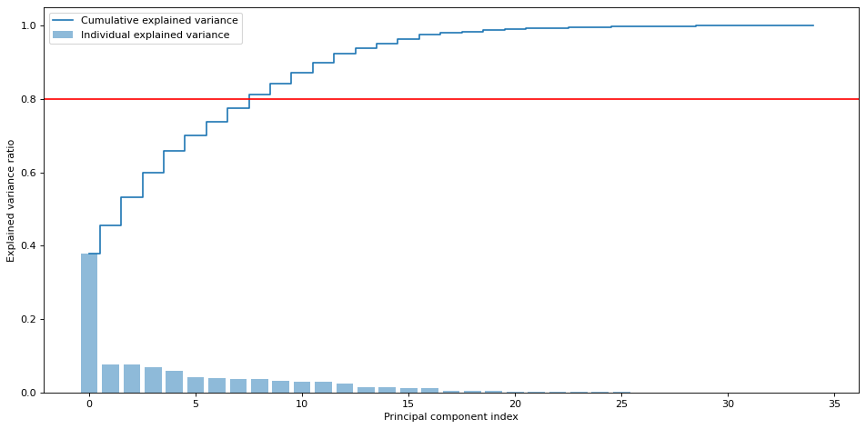

```python
exp_var_pca = pca.explained_variance_ratio_

cum_sum_eigenvalues = np.cumsum(exp_var_pca)

threshold = 0.8
plt.figure(figsize=(12, 6), dpi=80)
plt.bar(range(0,len(exp_var_pca)), exp_var_pca, alpha=0.5, align='center', label='Individual explained variance')
plt.step(range(0,len(cum_sum_eigenvalues)), cum_sum_eigenvalues, where='mid',label='Cumulative explained variance')
plt.axhline(y=threshold, color='r', linestyle='-')

plt.ylabel('Explained variance ratio')
plt.xlabel('Principal component index')
plt.legend(loc='best')
plt.tight_layout()
plt.show()
```

```python
pca_2 = PCA(n_components=7)

pca_2.fit(X_train_oversampled)
X_train_pca_2 = pca_2.transform(X_train_oversampled)
X_test_pca_2 = pca_2.transform(x_test)
```

```python
X_train_pca_2 = pd.DataFrame(X_train_pca_2)
X_test_pca_2 = pd.DataFrame(X_test_pca_2)
X_train_pca_2.columns = ['PCA_'+str(i) for i in X_train_pca_2.columns]
X_test_pca_2.columns = ['PCA_'+str(i) for i in X_test_pca_2.columns]
X_train_pca_2.head()
```

|  | PCA_0 | PCA_1 | PCA_2 | PCA_3 | PCA_4 | PCA_5 | PCA_6 |
| --- | --- | --- | --- | --- | --- | --- | --- |
| 0 | -0.927575 | -0.212683 | -0.445565 | 0.735867 | -1.253740 | -0.684189 | 0.276427 |
| 1 | -0.122397 | 1.384039 | -0.992900 | -0.662993 | -0.196894 | -0.392463 | -0.845808 |
| 2 | -0.190553 | -1.118294 | 0.542627 | -0.446356 | -0.262927 | 0.471750 | 0.904065 |
| 3 | -0.127923 | 0.550729 | -1.581597 | 0.548982 | 0.747190 | -0.438932 | 1.061781 |
| 4 | -0.136893 | -1.591669 | -1.058397 | -1.160679 | -0.166289 | 0.976375 | -0.948024 |

Estos nuevos conjuntos de training y testing nos servirá para hacer uso de ellos en los modelos y después comparar resultados.

# MODELOS

Antes de adentrarnos en los modelos, debemos fijar una serie de conceptos. Por un lado, hablemos de la *matriz de confusión*, de las *métricas* y de la *curva de ROC*.

**Matriz de confusión**. Las matrices de confusión se utilizan en problemas de clasificación. Cada columna de la matriz representa el número de predicciones de cada clase (en nuestro caso si habrá algún fallecido o no), mientras que cada fila representa lo ocurrido realmente. Esto es, en términos prácticos nos permite ver qué tipos de aciertos y errores está teniendo nuestro modelo a la hora de pasar por el proceso de aprendizaje con los datos.

**Métricas**. Las métricas sirven para determinar el rendimiento de un modelo y, existen muchos tipos de métricas. Muchas de ellas se basan en las matrices de confusión.

**Curva de ROC**. La curva de ROC es la representación gráfica de la sensibilidad(recall) frente a la especificidad. Una métrica muy conocida es el área bajo la curva de roc. Esta medida toma valores entre 1 y 0.5. Esta métrica puede interpretarse como la probabilidad de que ante un par de individuos, uno fallecido y el otro no, la prueba los clasifique correctamente.

Estas son dos de las grandes cosas en las que nos tenemos que fijar para determinar la eficacia de nuestro modelo. En nuestro caso, debemos tener en cuenta que nuestro dataset es un dataset desvalanceado y, por ello, no tiene sentido tomar todas las métricas igual de importantes. Es por ello, que para este proyecto, en las métricas que más nos fijaremos serán el *recall*, *la curva de roc y el área bajo su curva* y, por supuesto *la matriz de confusión normalizada*. ¿Por qué elegimos el recall? Teniendo en cuenta que nuestro objetivo es predecir los fallecimientos de la mejor manera posible, esta medida será una de las más importantes ya que es la división entre los fallecidos acertados correctamente y el total de fallecidos.

## MODELO GLM

Los modelos GLM o modelos lineales generalizados, como bien su nombre indica, son una generalización de los modelos de regresión lineal. Estos modelos aparecen en el momento que la variable target no es normal.

**Observación.** Recordemos que una de las condiciones de las regresiones lineales simples y múltiples es que la variable target debe ser normal.

Por ello, si queremos predecir el número de personas que entrará a una tienda o si queremos predecir si alguien tiene una enfermedad o no, debemos hacer uso de los GLM.

Para poder predecir diferentes variables target, no normales, lo que hacemos es usar una *función de link* que sea invertible, de tal forma que:

$g(E(Y|X)) = w_{0} + w_{1}*x_{1} + w_{2}*x_{2} + ... + w_{n}*x_{n}$

Esto se resume en que si, por ejemplo queremos que nuestra variable target sea una probabilidad, por ejemplo podemos hacer uso de la función *logit*, la cual se define de la siguiente forma:

$logit(p) = \dfrac{p}{1-p}$, donde $p$ es la probabilidad de éxito

Así, utilizando esta función, tendríamos la siguiente ecuación:

$logit(p(X)) = w_{0} + w_{1}*x_{1} + w_{2}*x_{2} + ... + w_{n}*x_{n}$

Y despejando p(X) tenemos:

$p(X) = \dfrac{e^{w_{0} + w_{1}*x_{1} + w_{2}*x_{2} + ... + w_{n}*x_{n}}}{1 + e^{w_{0} + w_{1}*x_{1} + w_{2}*x_{2} + ... + w_{n}*x_{n}}}$

Nosotros utilizaremos un caso particular de glm que es la *regresión logística*. En esta regresión, la función link de la que se hace uso es, por ejemplo, la función logit presentada anteriormente.

### Regresión logística con todas las variables

**Vatriables a utilizar**

- *X_train_oversampled*: Dataset de training con la técnica de oversampling sin la variable respuesta
- *y_train_oversampled*: Variable target con la técnica de oversampling
- *x_test*: Dataset de testing codificada mediante one hot encoding

**Librerias a utilizar**

- SelectFromModel from sklearn.feature_selection
- LogisticRegression, LinearRegression from sklearn.linear_model
- Sklearn.metrics

Primero hacemos el modelo con todas las variables que tenemos en el dataset. Después, realizaremos otra vez el modelo pero sólamente utilizando las variables que nos proporciona Lasso

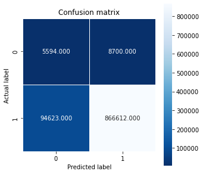

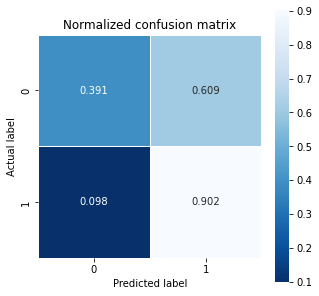

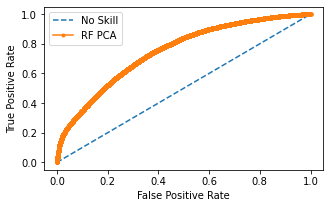

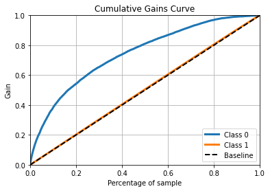

```python
start_LOGREG, final_LOGREG, prediction_LOGREG, predictions_proba_LOGREG, LOGREG= modelos(X_train_oversampled, y_train_oversampled, x_test, sklearn.linear_model.LogisticRegression(), ytest)
```

El modelo de regresión logística vemos que mejora notablemente el modelo base que hemos obtenido antes. Pero todavía se queda lejos de predecir bien los fallecimientos y, nosotros, como aseguradora, es nuestro principal interés.

```python
medidas(ytest, predictions_LOGREG, predictions_proba_LOGREG)
```

[output not shown]

La regresión logística mediante Lasso no ha podido ser calculada debido a que ha habido un problema con el notebook de los modelos y hemos tenido que ejecutar todo de nuevo y, la segunda parte de Lasso no ha podido ser calculada.

### Regresión logística con selección de variables de Lasso

En esta ocacasión haremos uso de las variables seleccionadas en la penalización Lasso y, comprobaremos si el modelo de regresión logística ha mejorado o no

```python
start_LOGREG, final_LOGREG, prediction_LOGREG, predictions_proba_LOGREG, LOGREG= modelos(X_train_oversampled, y_train_oversampled[selected_feat_lasso], x_test[selected_feat_lasso], sklearn.linear_model.LogisticRegression(), ytest)
```

[output not shown]

```python
medidas(ytest, predictions_LOGREG, predictions_proba_LOGREG)
```

[output not shown]

## SVM

**Def.** SVM (Supported Vector Machine) es un algoritmo tanto de clasificación como de regresión. El SVM sirve para poder separar las clases mediante un hiperplano. En dos dimensiones la separación se hace con una recta, en tres co un plano y en una dimensión n, mediante un hiperplano de dimensión n-1.

**Ejemplo.** A continuación mostramos una figura como ejemplo del objetivo del algoritmo SVM en dos dimensiones.

[figure not shown]

Como se puede observar, el principal objetivo del SVM es separar las dos clases de tal forma que las bolas rojas queden a un lado del hiperplano (recta en este caso) y las bolas azules al otro lado del hiperplano

**Vatriables a utilizar**

- *X_train_oversampled*: Dataset de training con la técnica de oversampling sin la variable respuesta
- *y_train_oversampled*: Variable target con la técnica de oversampling
- *x_test*: Dataset de testing

**Librerias a utilizar**

- SVC from sklearn.svm
- Sklearn.metrics

El modelo SVM no ha podido ejecutarse ya que ha estado apróximadamente unas 19 horas en ejecución y hemos tenido que detenerlo por falta de tiempo

Puesto que nuestro objetivo es intentar predecir el número de fallecidos que habrá en un accidente (valor 0 en nuestra variable target), dado que el RF tiene un parámetro que se conoce por *class_weight*, vamos a crear un bucle en el que variaremos el peso del valor 0 en nuestra variable target para ver cuál de todos nos produce una mejor matriz de confusión y mejores valores en las métricas.

Después, utilizaremos ese valor óptimo del bucle para ver los modelos RF con y sin PCA y después comparar resultados.

```python
for i in np.arange(3, 5, 0.5):
    RF = RandomForestClassifier(n_estimators=100, class_weight={0:i, 1:0.05}, random_state=42)
    RF.fit(X_train_oversampled, y_train_oversampled)
    prediccion_Random_Forest = RF.predict(x_test)
    predictions_proba_RF = RF.predict_proba(x_test)
    cm = confusion_matrix(ytest, prediccion_Random_Forest)
    cm_norm = confusion_matrix(ytest, prediccion_Random_Forest, normalize="true")

    plt.figure(figsize=(7,7))
    sns.heatmap(cm_gbt, annot=True, fmt=".3f", linewidths=1, square = True, cmap = 'Blues_r');
    plt.ylabel('Actual label');
    plt.xlabel('Predicted label');
    plt.title("Confusion matrix")

    plt.figure(figsize=(7,7))
    sns.heatmap(cm_gbt_norm, annot=True, fmt=".3f", linewidths=1, square = True, cmap = 'Blues_r');
    plt.ylabel('Actual label');
    plt.xlabel('Predicted label');
    plt.title("Normalized confusion matrix")
    print("Las métricas para i= ", i, "son:")
    print(medidas(ytest, prediccion_Random_Forest, predictions_proba_RF))
```

[output not shown]

## Random Forest

Antes de conocer el algoritmo de Random Forest, será necesario conocer primero los algoritmos de árboles de decisión.

**Def.** Los algoritmos de árboles de decisión, como bien su nombre indica, se basan en la representación de árbol donde cada nodo indica una variable y se separa en diferentes condiciones. Por ejemplo, si tengo una variable que me indica si una persona tiene coche o no, en el nodo de dicha variable el algoritmo se preguntará si tiene coche o no y en función de su respuesta recorrerá un camino u otro.

Una representación de un árbol de decisión es la que se ve a continuación:

[figure not shown]

**def.** El algoritmo de Random Forest es un algoritmo basado en árboles de decisión que sirve para resolver problemas de clasificación y de regresión. Este algoritmo es un claro ejemplo de técnica de ensamble de modelos. En otras palabras, Random Forest es el resultado de una combinación de modelos.

A la hora de hacer el ensamble existen dos grandes técnicas. Tenemos el ensamble por *bagging* y el ensamble por *boosting*. El algoritmo Random Forest es un ejemplo de técnica de bagging. Ahora bien, ¿en qué consiste la técnica de bagging? Esta técnica trata de seleccionar, de manera aleatoria, muestras y crear modelos un número finito de veces. De esta manera, si seleccionamos n muestras y creamos n modelos con todas las muestras y después combinamos los n modelos, estamos haciendo *bagging*.

En nuestro caso, trataremos el algoritmo RF como técnica de clasificación ya que lo que buscamos es predecir si un accidente tendrá o no fallecidos

**Variables a utilizar:**

- *X_train_oversampled*: Dataset de training con la técnica de oversampling sin la variable respuesta
- *y_train_oversampled*: Parte del training de la variable respuesta
- *x_test*: Dataset de testing

**Librerias a utilizar**

- RandomForestClassifier from sklearn.ensemble
- Sklearn.metrics

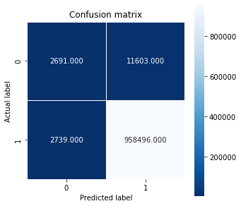

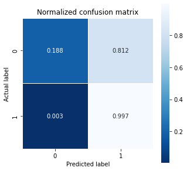

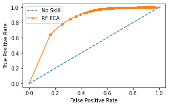

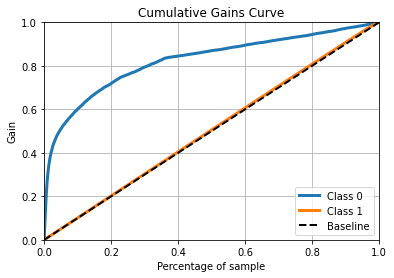

```python
start_RF, final_RF, prediction_RF, predictions_proba_RF, RF = modelos(X_train_oversampled, y_train_oversampled, x_test, RandomForestClassifier(class_weight={0:5, 1:0.05}, random_state=42), ytest)
```

Nuestro modelo clava los individuos de la clase 1 pero no los de la clase 0 (son quienes nos interesan), luego, deberemos modificar este modelo para que acierte más los individuos de la clase 0. ¿Cómo lo haremos? Lo conseguiremos considerando el threshold óptimo que nos proporciona la curva de ROC. Pero, ¿qué quiere decir esto que acabamos de decir? Debemos tener en cuenta que, el algoritmo, por defecto nos devuelve una probabilidad como predicción. Luego, el propio algoritmo se encarga de decidir a qué clase pertenece cada predicción en función de la probabilidad. Y, esta probabilidad, por defecto es 0.5. Esto quiere decir que, si la probabilidad devuelta por el algoritmo para un individuo i es mayor que 0.5, lo clasifica como de la clase 1, mientras que si por el contrario es menor o igual que 0.5, lo clasifica como de la clase 0. Luego, este umbral lo tenemos que introducir nosotros manualmente para que el problema sea real, puesto que no siempre es interesante que se divida en el valor 0.5. Y este umbral (o también conocido como threshold) nos lo dará la curva de ROC.

LA curva de ROC, como hemos explicado antes, es la representación gráfica del recall frente a la especificidad y lo que nos interesa es encontrar el punto óptimo entre recall y sensitividad. Ese punto óptimo será nuestro threshold. Veamos a continuación como podemos calcularlo.

##### THRESHOLD ÓPTIMO MEDIANTE LA CURVA DE ROC

```python
yhat_RF = predictions_proba_RF[:, 1]
fpr_RF, tpr_RF, thresholds_RF = roc_curve(ytest, yhat_RF)
```

```
Best Threshold=0.980392, F-Score=0.763
```

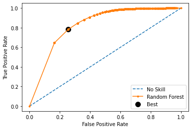

```python
gmeans_RF = np.sqrt(tpr_RF * (1-fpr_RF))
ix_RF = np.argmax(np.sqrt(tpr_RF * (1-fpr_RF)))
predictions_roc_RF=(predictions_proba_RF[:,1] >= thresholds_RF[ix_RF]).astype(int)
print('Best Threshold=%f, F-Score=%.3f' % (thresholds_RF[ix_RF], gmeans_RF[ix_RF]))

plt.plot([0,1], [0,1], linestyle='--', label='No Skill')
plt.plot(fpr_RF, tpr_RF, marker='.', label='Random Forest')
plt.scatter(fpr_RF[ix_RF], tpr_RF[ix_RF], s=100, marker='o', color='black', label='Best')
# axis labels
plt.xlabel('False Positive Rate')
plt.ylabel('True Positive Rate')
plt.legend()
# show the plot
plt.show()
```

Para nuestro modelo, el threshold óptimo se da en 0.98. Luego, con el vector de predicciones nuevo calculado, volvemos a sacar las matrices de confusión.

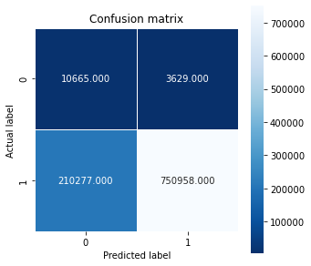

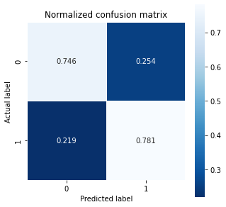

```python
cm_RF_roc = confusion_matrix(ytest, predictions_roc_RF)
cm_norm_RF_roc = confusion_matrix(ytest, predictions_roc_RF, normalize="true")

plt.figure(figsize=(5,5))
sns.heatmap(cm_RF_roc, annot=True, fmt=".3f", linewidths=1, square = True, cmap = 'Blues_r');
plt.ylabel('Actual label');
plt.xlabel('Predicted label');
plt.title("Confusion matrix")

plt.figure(figsize=(5,5))
sns.heatmap(cm_norm_RF_roc, annot=True, fmt=".3f", linewidths=1, square = True, cmap = 'Blues_r');
plt.ylabel('Actual label');
plt.xlabel('Predicted label');
plt.title("Normalized confusion matrix")
```

El rendimiento del modelo ha incrementado notablemente al considerar las nuevas predicciones que hemos calculado mediante el threshold óptimo. Tenemos un total de aciertos en fallecidos de casi el 75%, lo cual no es del todo una mala cifra. Veamos los resultado numéricos analizando los resultados de las diferentes métricas.

##### MÉTRICAS

```python
medidas(ytest, predictions_roc_RF, predictions_proba_RF)
```

|  | F1 | roc_score | accuracy | recall |
| --- | --- | --- | --- | --- |
| 0 | 0.875333 | 0.830844 | 0.780728 | 0.781243 |

Ahora, guardamos el modelo en un formato pickle con el nombre *RF*

```python
with open('../Models/RF.pickle', 'wb') as f:
    pickle.dump(RF, f)
```

Ahora, vamos a plantear el mismo algoritmo de RF pero únicamente introduciendo las componentes obtenidas en el PCA. Después, compararemos los resultados obtenidos y finalmente, decidiremos si merece la pena introducir el PCA en el algoritmo RF o no.

### Random Forest con PCA

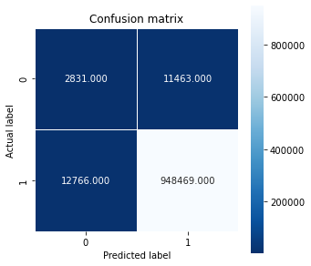

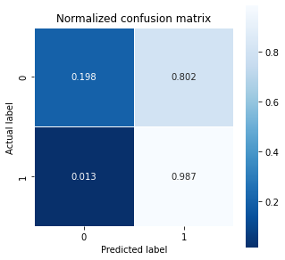

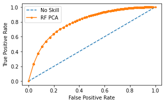

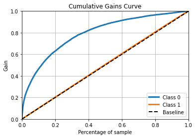

```python
start_RF_PCA, final_RF_PCA, prediction_RF_PCA, predictions_proba_RF_PCA, RF_PCA= modelos(X_train_pca_2, y_train_oversampled, X_test_pca_2, RandomForestClassifier(class_weight={0:5.1, 1:0.05}, random_state=42), ytest)
```

##### THRESHOLD ÓPTIMO MEDIANTE LA CURVA DE ROC

```python
yhat_RF_PCA = predictions_proba_RF_PCA[:, 1]
fpr_RF_PCA, tpr_RF_PCA, thresholds_RF_PCA = roc_curve(ytest, yhat_RF_PCA)
```

```
Best Threshold=0.920194, F-Score=0.725
```

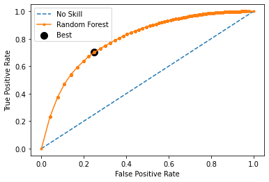

```python
gmeans_RF_PCA = np.sqrt(tpr_RF_PCA * (1-fpr_RF_PCA))
ix_RF_PCA = np.argmax(np.sqrt(tpr_RF_PCA * (1-fpr_RF_PCA)))
predictions_roc_RF_PCA=(predictions_proba_RF_PCA[:,1] >= thresholds_RF_PCA[ix_RF_PCA]).astype(int)
print('Best Threshold=%f, F-Score=%.3f' % (thresholds_RF_PCA[ix_RF_PCA], gmeans_RF_PCA[ix_RF_PCA]))

plt.plot([0,1], [0,1], linestyle='--', label='No Skill')
plt.plot(fpr_RF_PCA, tpr_RF_PCA, marker='.', label='Random Forest')
plt.scatter(fpr_RF_PCA[ix_RF_PCA], tpr_RF_PCA[ix_RF_PCA], s=100, marker='o', color='black', label='Best')
# axis labels
plt.xlabel('False Positive Rate')
plt.ylabel('True Positive Rate')
plt.legend()
# show the plot
plt.show()
```

Repetimos las matrices de confusión considerando el threshold ofrecido por la curva ROC:

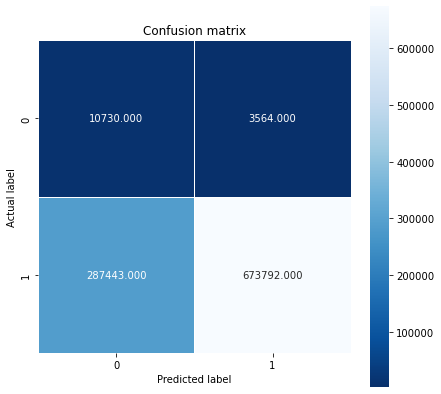

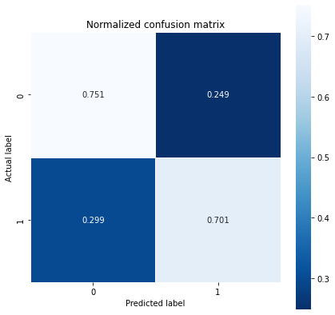

```python
cm_RF_PCA_roc = confusion_matrix(ytest, predictions_roc_RF_PCA)
cm_norm_RF_PCA_roc = confusion_matrix(ytest, predictions_roc_RF_PCA, normalize="true")

plt.figure(figsize=(5,5))
sns.heatmap(cm_RF_PCA_roc, annot=True, fmt=".3f", linewidths=1, square = True, cmap = 'Blues_r');
plt.ylabel('Actual label');
plt.xlabel('Predicted label');
plt.title("Confusion matrix")

plt.figure(figsize=(5,5))
sns.heatmap(cm_norm_RF_PCA_roc, annot=True, fmt=".3f", linewidths=1, square = True, cmap = 'Blues_r');
plt.ylabel('Actual label');
plt.xlabel('Predicted label');
plt.title("Normalized confusion matrix")
```

Las matrices de confusión han mejorado, como era de esperar, hasta llegar a un 75% de aciertos para los individuos de la clase 0. Sin embargo, si comparamos las matrices obtenidas con el RF sin PCA y estas, podemos observar que las matrices del primer modelo son bastante mejores que estas, es por ello que se concluye que no merece la pena utilizar el PCA en este caso. Después veremos los tiempos de ejecución para comparar.

Veamos las métricas de este modelo.

##### MÉTRICAS

```python
medidas(ytest, predictions_roc_RF_PCA, predictions_proba_RF_PCA)
```

|  | F1 | roc_score | accuracy | recall |
| --- | --- | --- | --- | --- |
| 0 | 0.822404 | 0.798518 | 0.701693 | 0.700965 |

Se demuestra lo mencionado anteriormente, tanto el recall como el área bajo la curva ROC son menores que en el primer modelo. Luego, el primer modelo supera al RF con PCA en términos de resultados. Veamos qué ocurre con el tiempo.

Ahora, guardamos el modelo en un formato pickle con el nombre *RF_PCA*

```python
with open('../Models/RF_PCA.pickle', 'wb') as f:
    pickle.dump(RF_PCA, f)
```

##### CONCLUSIONES

Primeramente, los tiempos de ejecución para ambos modelos es el siguiente:

```python
time_RF = [start_RF, final_RF]
time_RF_PCA = [start_RF_PCA, final_RF_PCA]
data_time_RF = {"RF": time_RF, "RF_PCA":time_RF_PCA}
time_RF = pd.DataFrame(data_time_RF, columns=["RF", "RF_PCA"])
time_RF.index=["start", "end"]
time_RF = time_RF.transpose()
time_RF["total_time(s)"] = time_RF["end"]-time_RF["start"]
time_RF
```

|  | start | end | total_time(s) |
| --- | --- | --- | --- |
| RF | 1.639939e+09 | 1.639942e+09 | 3175.121493 |
| RF_PCA | 1.639942e+09 | 1.639948e+09 | 5688.069708 |

En términos de cómputo, resulta curioso que en este caso el modelo que más ha tardado ha sido el modelo en el que hacemos uso de PCA y la diferencia es bastante grande, casi el doble. Además, hemos podido comprobar que el RandomForest nos ha proporcionado mejores resultados. Luego, claramente el modelo con el que nos quedamos es el guardado con el nombre RF.

## XGBoost

**Def.** El algoritmo XGBBoost, al igual que el Random Forest, es un algoritmo de ensamble basado en árboles de decisión.

Este algoritmo también hace uso de la técnica de ensamblaje pero lo hace mediante boosting. ¿En qué consiste el boosting? En bagging, todos los datos tienen la misma probabilidad de ser elegidos en cada iteración. Sin embargo, en boosting no ocurre esto. Esto se resume en que la técnica de boosting insiste más en lo que más se falla. En otras palabras, en cada iteración, este algoritmo asigna una serie de pesos a cada punto del dataset, en función de los fallos que encuentre en la iteración anterior.

Esto puede tener ventajas y desventajas frente al random forest. La gran ventaja es que es más preciso pero, la mayor desventaja es el tiempo de ejecución ya que XGBoost no puede empezar con la siguiente iteración sin haber acabado la anterior.

**Variables a utilizar:**

- *X_train_oversampled*: Dataset de training con la técnica de oversampling sin la variable respuesta
- *y_train_oversampled*: Parte del training de la variable respuesta
- *x_test*: Dataset de testing modificado con la función de escalado

**Librerias a utilizar**

- Xgboost as xgb
- Sklearn.metrics
- XGBClassifier from xgboost

```
[19:19:51] WARNING: ../src/learner.cc:1115: Starting in XGBoost 1.3.0, the default evaluation metric used with the objective 'binary:logistic' was changed from 'error' to 'logloss'. Explicitly set eval_metric if you'd like to restore the old behavior.
```

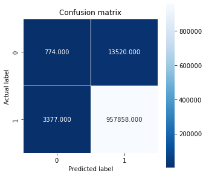

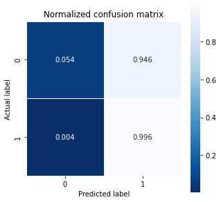

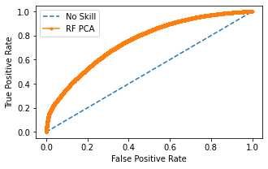

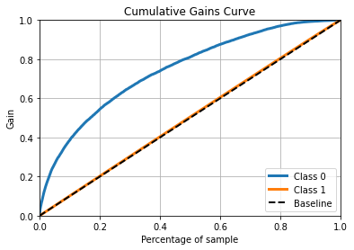

```python
start_XGB, final_XGB, prediction_XGB, predictions_proba_XGB, XGB= modelos(X_train_oversampled, y_train_oversampled, x_test, XGBClassifier(), ytest)
```

A primera vista, el modelo es realmente malo. Luego, para mejorar el rendimiento del mismo, deberemos calcular el threshold óptimo mediante la curva de ROC al igual que lo hemos hecho para los casos de RandomForest.

##### THRESHOLD ÓPTIMO MEDIANTE LA CURVA DE ROC

```python
yhat_XGB = predictions_proba_XGB[:, 1]
fpr_XGB, tpr_XGB, thresholds_XGB = roc_curve(ytest, yhat_XGB)
```

```
Best Threshold=0.941122, F-Score=0.681
```

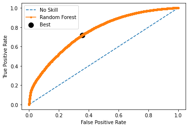

```python
gmeans_XGB = np.sqrt(tpr_XGB * (1-fpr_XGB))
ix_XGB = np.argmax(np.sqrt(tpr_XGB * (1-fpr_XGB)))
predictions_roc_XGB=(predictions_proba_XGB[:,1] >= thresholds_XGB[ix_XGB]).astype(int)
print('Best Threshold=%f, F-Score=%.3f' % (thresholds_XGB[ix_XGB], gmeans_XGB[ix_XGB]))

plt.plot([0,1], [0,1], linestyle='--', label='No Skill')
plt.plot(fpr_XGB, tpr_XGB, marker='.', label='Random Forest')
plt.scatter(fpr_XGB[ix_XGB], tpr_XGB[ix_XGB], s=100, marker='o', color='black', label='Best')
# axis labels
plt.xlabel('False Positive Rate')
plt.ylabel('True Positive Rate')
plt.legend()
# show the plot
plt.show()
```

##### MATRICES DE CONFUSIÓN CON THRESHOL ÓPTIMO

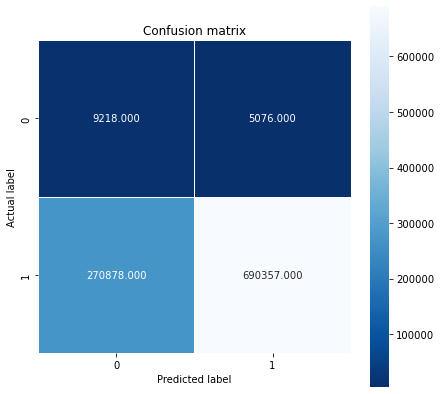

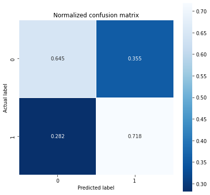

```python
cm_XGB_roc = confusion_matrix(ytest, predictions_roc_XGB)
cm_norm_XGB_roc = confusion_matrix(ytest, predictions_roc_XGB, normalize="true")

plt.figure(figsize=(5,5))
sns.heatmap(cm_XGB_roc, annot=True, fmt=".3f", linewidths=1, square = True, cmap = 'Blues_r');
plt.ylabel('Actual label');
plt.xlabel('Predicted label');
plt.title("Confusion matrix")

plt.figure(figsize=(5,5))
sns.heatmap(cm_norm_XGB_roc, annot=True, fmt=".3f", linewidths=1, square = True, cmap = 'Blues_r');
plt.ylabel('Actual label');
plt.xlabel('Predicted label');
plt.title("Normalized confusion matrix")
```

Vemos como el modelo ha cambiado completamente. Acertamos más que antes, pero seguimos estando lejos del objetivo de predecir los fallecidos ya que fallamos demasiado. Es por ello que, viendo el modelo de RandomForest que hemos obtenido anteriormente, este modelo no nos dice gran cosa. Veamos cuáles son los valores de las métricas.

##### MÉTRICAS

```python
medidas(ytest, prediction_XGB, predictions_proba_XGB)
```

|  | F1 | roc_score | accuracy | recall |
| --- | --- | --- | --- | --- |
| 0 | 0.991257 | 0.751337 | 0.982679 | 0.996487 |

Ahora, guardamos el modelo en un formato pickle con el nombre *XGB*

```python
with open('../Models/XGB.pickle', 'wb') as f:
    pickle.dump(XGB, f)
```